# Debugging and Condition Handling

36-350 – Statistical Computing

Week 8 – Fall 2020

# R: Stuff Happens

There are three so-called *conditions* in `R`: errors, warnings, and messages. (Note that to get the code chunk below to run, I added the option `error=TRUE` at the beginning. Keep this in mind for situations where your .Rmd file won’t knit.)

```r
x = "a"
if ( typeof(x) != "numeric") stop("x must be numeric.")      # Error: communicated via stop()
```

```
## Error in eval(expr, envir, enclos): x must be numeric.
```

```r
if ( typeof(x) != "numeric") warning("x should be numeric.") # Warning: communicated via warning()
```

```
## Warning: x should be numeric.
```

```r
message("Welcome to the first code chunk of Notes_8B!")     # Message: communicated via message()
```

```
## Welcome to the first code chunk of Notes_8B!
```

This is not necessarily good coding practice, but if you want to suppress warnings and messages…

```r
suppressWarnings(warning("This is your final warning!"))           # ...but it isn't, probably
suppressMessages(message("You don't want to miss this message!"))  # ...but you will
```

# Debugging: General Philosophies (Borrowed from Hadley Wickham, As Usual)

- Realize you have a bug. (This is a call for [unit testing](http://r-pkgs.had.co.nz/tests.html), which we’ll cover next.)
- Make it repeatable. (There’s nothing like a bug that disappears because you forgot the steps you took prior to observing it, or because you didn’t use `set.seed()` before sampling numbers, or…)
- Figure out where it is. (In `RStudio`, this may involve highlighting smaller and smaller bits of code chunks and running those bits, to see where things are not as they should be. More on this below.)
- Fix it and test it. (Meaning: add a unit test to ensure that the bug is squished and stays gone.)

# Debugging: R Markdown & Browser()

`R Markdown` does not currently support the concept of a breakpoint, where you click to the left of the line number and a red dot appears:

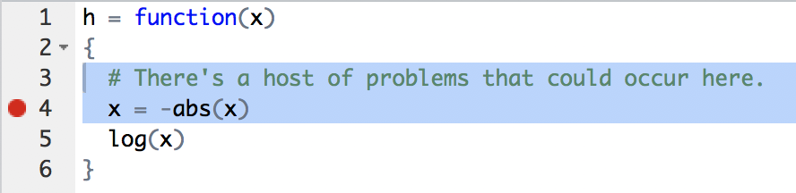

What you *can* do is suspend the execution of a code chunk via use of the `browser()` function:

```r
x = 5
#browser() # uncomment in real-life usage...execution stops here and a "Browse" prompt appears in the console
x = -abs(x)
log(x)     # only yields a warning if a negative number is input
```

```
## [1] NaN
```

# Debugging: R Markdown & Browser()

An example of using `browser()`:

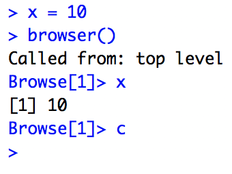

In the browser, you can check the values of variables and move forward through your code. See `?browser` for a list of commands that you can issue at the prompt. Common ones are

- `c` or `cont`: exit the browser and continue execution at the next statement
- `n`: evaluate the next statement, stepping over function calls
- `s`: evaluate the next statement, stepping into function calls

# Debugging: R Markdown & traceback()

The `traceback()` function allows one to determine at what level of nested function calls an error occurs:

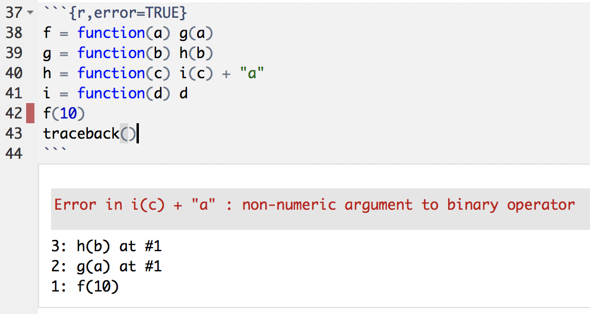

(Note that while `traceback()` offers potentially useful information when running a code chunk, that information is not preserved during knitting. That’s why I have a screenshot here, rather than a code chunk within this knitted slide.)

# Condition Handling: try()

The `try()` function allows you to ignore errors:

```r
f = function(x) { try(log(x)) }
f(10)
```

```
## [1] 2.302585
```

```r
f("x")
```

```
## Error in log(x) : non-numeric argument to mathematical function
```

```r
f = function(x) {
  try(
    {
      x = -abs(x)
      log(x)
    },silent=TRUE) # Not necessarily a good coding practice! (And only suppresses errors.)
}
f(10)
```

```
## [1] NaN
```

```r
f("x")
```

# Condition Handling: tryCatch()

The `tryCatch()` function allows you to customize your responses to conditions. The usual structure is something like this:

```
 tryCatch({
   <code that may fail>
   },
   error = function(c) { < deal with error here > },
   warning = function(c) { < deal with warning here > },
   message = function(c) { < issue message here > },
   finally = { < stuff to do regardless if there is an error > }
 )
```

You need not specify every argument to `tryCatch()`. For instance, it is a relatively rare that your code will yield a message when run, so often you need not worry about what to do if a message is output.

# Condition Handling: tryCatch()

```r
f = function(x) {
  tryCatch(log(x),
    error = function(c) "Error: input is not a number.",
    warning = function(c) "Warning: input is a negative number."
  )
}
f(10)  # bueno
```

```
## [1] 2.302585
```

```r
f(-10) # malo
```

```
## [1] "Warning: input is a negative number."
```

```r
f("x") # muy malo
```

```
## [1] "Error: input is not a number."
```